# Test

# Preparation

## Loading necessary packages

```r
library(data.table)
library(ggplot2)
library(xlsx)
library(lubridate)
library(DataExplorer)
library(missRanger)
library(e1071)
library(knitr)

set.seed(19880303)
options(scipen = 999)
```

## Loading the data

```r
meta <- data.table(read.xlsx('LCDataDictionary.xlsx', 1))
meta <- meta[,1:2]

dt <- fread('loan.csv', stringsAsFactors = T)
```

```
|--------------------------------------------------|
|==================================================|
```

```r
dt <- dt[,c('loan_amnt','funded_amnt','term','int_rate','grade','annual_inc','issue_d','dti','revol_bal','total_pymnt','loan_status')]
dt[,issue_d := dmy(paste0('01-',issue_d))] # make datetime out of month column
```

## Exploring the data

All columns appear to be of the proper type. Right now, I don’t see a reason to make the column ‘term’ continuous.

```r
str(dt)
```

```
Classes ‘data.table’ and 'data.frame':  2260668 obs. of  11 variables:
 $ loan_amnt  : int  2500 30000 5000 4000 30000 5550 2000 6000 5000 6000 ...
 $ funded_amnt: int  2500 30000 5000 4000 30000 5550 2000 6000 5000 6000 ...
 $ term       : Factor w/ 2 levels "36 months","60 months": 1 2 1 1 2 1 1 1 1 1 ...
 $ int_rate   : num  13.6 18.9 18 18.9 16.1 ...
 $ grade      : Factor w/ 7 levels "A","B","C","D",..: 3 4 4 4 3 3 4 3 4 3 ...
 $ annual_inc : num  55000 90000 59280 92000 57250 ...
 $ issue_d    : Date, format: "2018-12-01" "2018-12-01" "2018-12-01" "2018-12-01" ...
 $ dti        : num  18.2 26.5 10.5 16.7 26.4 ...
 $ revol_bal  : int  4341 12315 4599 5468 829 53854 0 38476 8018 65950 ...
 $ total_pymnt: num  167 1507 354 287 1423 ...
 $ loan_status: Factor w/ 9 levels "Charged Off",..: 2 2 2 2 2 2 2 2 2 2 ...
 - attr(*, ".internal.selfref")=<externalptr>
```

Some findings: * The column ‘funded_amt’ seems to be closely matching the ‘loan_amt’ column. * There are some missing values in the ‘annual_inc’ and ‘dti’ columns

```r
summary(dt)
```

```
   loan_amnt      funded_amnt           term            int_rate     grade        annual_inc           issue_d                dti
 Min.   :  500   Min.   :  500   36 months:1609754   Min.   : 5.31   A:433027   Min.   :        0   Min.   :2007-06-01   Min.   : -1.00
 1st Qu.: 8000   1st Qu.: 8000   60 months: 650914   1st Qu.: 9.49   B:663557   1st Qu.:    46000   1st Qu.:2015-04-01   1st Qu.: 11.89
 Median :12900   Median :12875                       Median :12.62   C:650053   Median :    65000   Median :2016-07-01   Median : 17.84
 Mean   :15047   Mean   :15042                       Mean   :13.09   D:324424   Mean   :    77992   Mean   :2016-05-02   Mean   : 18.82
 3rd Qu.:20000   3rd Qu.:20000                       3rd Qu.:15.99   E:135639   3rd Qu.:    93000   3rd Qu.:2017-11-01   3rd Qu.: 24.49
 Max.   :40000   Max.   :40000                       Max.   :30.99   F: 41800   Max.   :110000000   Max.   :2018-12-01   Max.   :999.00
                                                                     G: 12168   NA's   :4                                NA's   :1711
   revol_bal        total_pymnt                loan_status
 Min.   :      0   Min.   :    0   Fully Paid        :1041952
 1st Qu.:   5950   1st Qu.: 4273   Current           : 919695
 Median :  11324   Median : 9061   Charged Off       : 261655
 Mean   :  16659   Mean   :11824   Late (31-120 days):  21897
 3rd Qu.:  20246   3rd Qu.:16708   In Grace Period   :   8952
 Max.   :2904836   Max.   :63297   Late (16-30 days) :   3737
                                   (Other)           :   2780
```

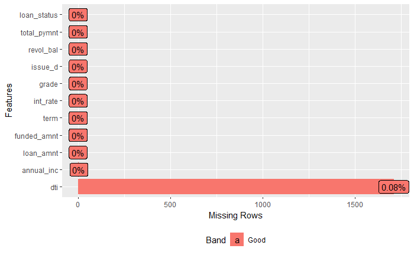

```r
plot_missing(dt)
```

There are several ways we can handle the missing values: * Using the mean of the column * Impute using the same distribution as the known values * Omit the rows with missing values * A machine learning approach

I preferchoosing the latter and impute by chaining random forests. The *missRanger* package offers a very easy interface in order to achieve this. However, given the size of the data set, let’s just impute with the median (skewed data, no mean).

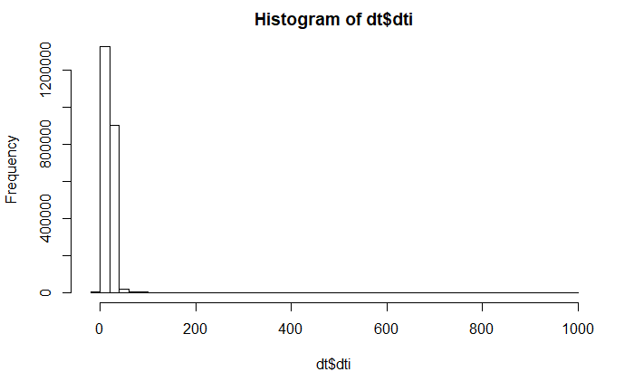

```r
# dt_imputed <- missRanger(dt,. ~ ., maxiter = 5, verbose = T, seed = 19880303, splitrule = 'extratrees', num.trees = 25)

hist(dt$dti, breaks = 50)
```

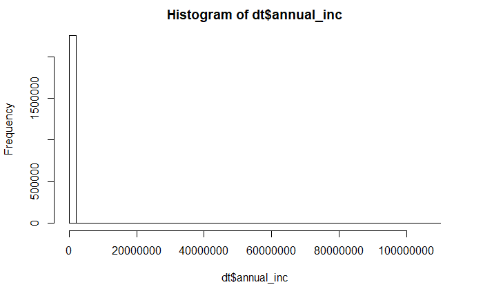

```r
hist(dt$annual_inc, breaks = 50)
```

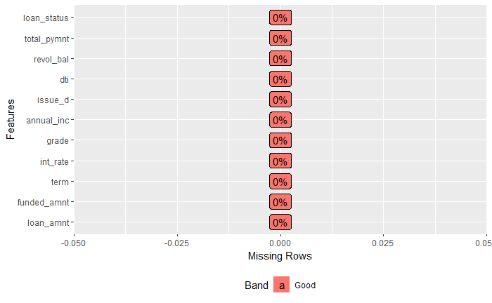

```r
dt_imputed <- copy(dt)
dt_imputed[is.na(annual_inc), annual_inc := median(dt$annual_inc, na.rm = T)]
dt_imputed[is.na(dti), dti := median(dt$dti, na.rm = T)]

plot_missing(dt_imputed)
```

```r
dt <- copy(dt_imputed)
rm(dt_imputed)
```

# Exploratory Data Analysis

## Distribution of the data

To speed up the exploratory data analysis I have taken a sample of 250k objects.

```r
dt_eda <- dt[sample(.N,250000)]
```

Key findings: * The ‘loan_amt’ and ‘funded_amt’ seem to have heavy right tails. There also appears to be a bias to rounded numbers. * The variables ‘dti’ and ‘annual_inc’ seem to reflect inequalities that you expect from distributions regarding income. * ‘int_rate’ is *somewhat* normally distributed, but has fat tails (leptokurtic).

```r
plot_histogram(dt_eda)

jpeg("eda_plot1.jpg", width = 1600, height = 900)
```

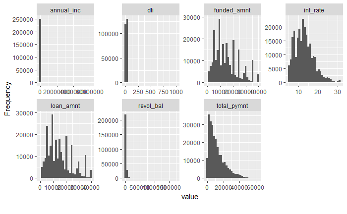

```r
plot_histogram(dt_eda)
dev.off()
```

```r
qqnorm(dt_eda$int_rate)
jpeg("eda_plot2.jpg", width = 1600, height = 900)
```

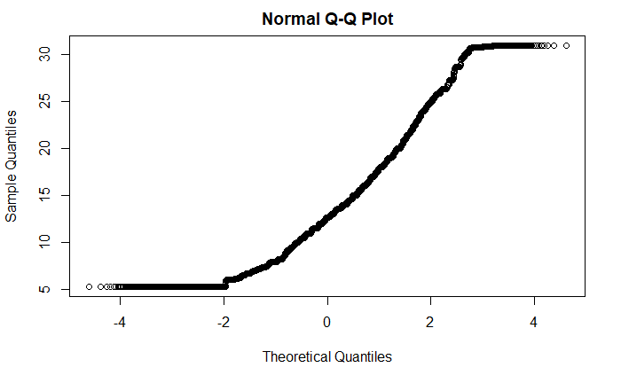

```r
qqnorm(dt_eda$int_rate)
dev.off()
```

```r
kurtosis(dt_eda$int_rate)
```

```
[1] 0.5833287
```

## Multicolinearity within the data

In this chunk I look at the correlation between the variables.

```r
plot_correlation(dt[,colnames(dt_eda)[grepl('numeric|integer',sapply(dt_eda,class))],with=F])
# plot_correlation(dt[,-c('issue_d')])
jpeg("eda_plot3.jpg", width = 1600, height = 900)
```

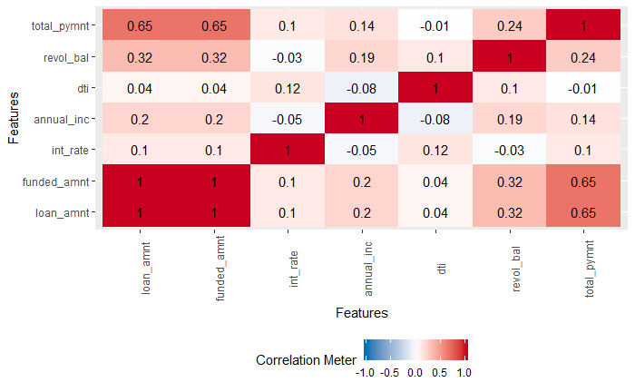

```r
plot_correlation(dt[,-c('issue_d')])
dev.off()
```

```r
rm(dt_eda)
```

## Time series analysis

Finally, I also plot the amount of provided loans over time.

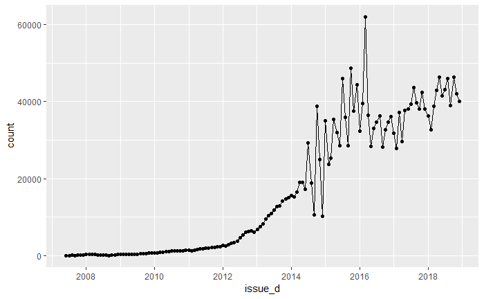

```r
ggplot(dt[,.(count = .N), by=.(issue_d)], aes(x = issue_d, y = count, group = 1)) + geom_line() + geom_point()
ggsave('eda_plot4.jpg', width = 8, height = 6)
```

```r
rm(g1)
```

```
object 'g1' not found
```

# Exploratory Data Analysis

First, let’s get rid of loans we haven’t tracked for 36 months in the data set. This leaves us with 890k loans.

```r
dt[,term := NULL] # assume all loan periods to be 36 months
max_date <- max(dt$issue_d) - months(36)
sum(dt$issue_d <= max_date)
```

```
[1] 887440
```

```r
dt2 <- dt[dt$issue_d <= max_date,]
```

## What percentage of loans has been fully paid?

75.6% of loans has been fully paid.

```r
unique(dt2$loan_status)
```

```
[1] Fully Paid                                          Charged Off
[3] Late (31-120 days)                                  Current
[5] In Grace Period                                     Late (16-30 days)
[7] Does not meet the credit policy. Status:Fully Paid  Does not meet the credit policy. Status:Charged Off
9 Levels: Charged Off Current Default ... Late (31-120 days)
```

```r
print(dt2[,.(count = .N/nrow(dt2) * 100), by=.(loan_status)])
```

| loan_status | count |
| --- | --- |
| Fully Paid | 75.62866222 |
| Charged Off | 17.09039484 |
| Late (31-120 days) | 0.21815559 |
| Current | 6.61396827 |
| In Grace Period | 0.10344361 |
| Late (16-30 days) | 0.03560804 |
| Does not meet the credit policy. Status:Fully Paid | 0.22401514 |
| Does not meet the credit policy. Status:Charged Off | 0.08575228 |

First, I set everything that is not fully paid to “Default”. Next, I created a ‘year’ column.

I aggregated the table by year and bucket, counting the amount of rows as value. Then, I pivoted the data, with ‘grade’ and ‘year’ as rows, status as columns. Finally, I calculated the share of defaults.

As you can see, loans rated G from 2008 performed the worst, but this is a really small cohort. I list the flop 10.

```r
dt3 <- copy(dt2)

dt3[,status := 'Fully Paid']
dt3[loan_status != 'Fully Paid', status := 'Default']
dt3[,year := year(issue_d)]
dt3 <- dcast.data.table(dt3[,.(count = .N), by =.(grade, year, status)], 'grade + year ~ status')
dt3[,share_default := round(Default / (`Default` + `Fully Paid`),2)]
kable(head(dt3[order(-share_default)],10))
```

| grade | year | Default | Fully Paid | share_default |
| --- | --- | --- | --- | --- |
| G | 2008 | 84 | 2 | 0.98 |
| E | 2007 | 91 | 9 | 0.91 |
| F | 2007 | 47 | 5 | 0.90 |
| F | 2008 | 100 | 11 | 0.90 |
| D | 2007 | 77 | 22 | 0.78 |
| E | 2008 | 222 | 63 | 0.78 |
| G | 2009 | 40 | 15 | 0.73 |
| D | 2008 | 251 | 168 | 0.60 |
| F | 2015 | 5857 | 3960 | 0.60 |
| G | 2015 | 1301 | 866 | 0.60 |

```r
rm(dt3)
```

In the following chunk I list the top 10 of year/grades with the highest annualized rate of return.

```r
dt4 <- copy(dt2)
dt4[,year := year(issue_d)]

dt4 <- dt4[,.(count = .N, total_payment = sum(total_pymnt), funded_amount = sum(funded_amnt)), by =.(grade, year)]
dt4[,aror := (total_payment / funded_amount) ^ (1/3) - 1]
kable(head(dt4[order(-aror)],10))
```

| grade | year | count | total_payment | funded_amount | aror |
| --- | --- | --- | --- | --- | --- |
| F | 2012 | 1315 | 39238871 | 32725200 | 0.0623755 |
| E | 2013 | 9059 | 193169586 | 161329875 | 0.0618781 |
| G | 2013 | 864 | 23432918 | 19582525 | 0.0616611 |
| G | 2010 | 133 | 2764399 | 2325750 | 0.0592844 |
| G | 2012 | 261 | 8117194 | 6841100 | 0.0586685 |
| F | 2013 | 4393 | 100151755 | 84437225 | 0.0585423 |
| E | 2012 | 3185 | 83035621 | 70187775 | 0.0576314 |
| E | 2011 | 1739 | 35299266 | 29926050 | 0.0565874 |
| F | 2011 | 722 | 16551425 | 14047225 | 0.0562052 |
| G | 2011 | 203 | 4955207 | 4256250 | 0.0519898 |

```r
rm(dt4)
```